# Risk Factor Analysis

## Outcome Variable

**Outcome Variable:** wast_rec90d

## Predictor Variables

**Intervention Variable:** hhwealth_quart

**Adjustment Set:**

unadjusted

## Stratifying Variables

The analysis was stratified on these variable(s):

- agecat
- studyid
- country

## Data Summary

| agecat | studyid | country | hhwealth_quart | wast_rec90d | n_cell | n |
| --- | --- | --- | --- | --- | --- | --- |
| 0-24 months | COHORTS | GUATEMALA | Wealth Q4 | 0 | 68 | 368 |
| 0-24 months | COHORTS | GUATEMALA | Wealth Q4 | 1 | 55 | 368 |
| 0-24 months | COHORTS | GUATEMALA | Wealth Q1 | 0 | 44 | 368 |
| 0-24 months | COHORTS | GUATEMALA | Wealth Q1 | 1 | 43 | 368 |
| 0-24 months | COHORTS | GUATEMALA | Wealth Q2 | 0 | 44 | 368 |
| 0-24 months | COHORTS | GUATEMALA | Wealth Q2 | 1 | 33 | 368 |
| 0-24 months | COHORTS | GUATEMALA | Wealth Q3 | 0 | 48 | 368 |
| 0-24 months | COHORTS | GUATEMALA | Wealth Q3 | 1 | 33 | 368 |
| 0-24 months | COHORTS | PHILIPPINES | Wealth Q4 | 0 | 135 | 1689 |
| 0-24 months | COHORTS | PHILIPPINES | Wealth Q4 | 1 | 269 | 1689 |
| 0-24 months | COHORTS | PHILIPPINES | Wealth Q1 | 0 | 183 | 1689 |
| 0-24 months | COHORTS | PHILIPPINES | Wealth Q1 | 1 | 256 | 1689 |
| 0-24 months | COHORTS | PHILIPPINES | Wealth Q2 | 0 | 127 | 1689 |
| 0-24 months | COHORTS | PHILIPPINES | Wealth Q2 | 1 | 159 | 1689 |
| 0-24 months | COHORTS | PHILIPPINES | Wealth Q3 | 0 | 219 | 1689 |
| 0-24 months | COHORTS | PHILIPPINES | Wealth Q3 | 1 | 341 | 1689 |
| 0-6 months | COHORTS | GUATEMALA | Wealth Q4 | 0 | 18 | 207 |
| 0-6 months | COHORTS | GUATEMALA | Wealth Q4 | 1 | 54 | 207 |
| 0-6 months | COHORTS | GUATEMALA | Wealth Q1 | 0 | 9 | 207 |
| 0-6 months | COHORTS | GUATEMALA | Wealth Q1 | 1 | 41 | 207 |
| 0-6 months | COHORTS | GUATEMALA | Wealth Q2 | 0 | 7 | 207 |
| 0-6 months | COHORTS | GUATEMALA | Wealth Q2 | 1 | 29 | 207 |
| 0-6 months | COHORTS | GUATEMALA | Wealth Q3 | 0 | 17 | 207 |
| 0-6 months | COHORTS | GUATEMALA | Wealth Q3 | 1 | 32 | 207 |
| 0-6 months | COHORTS | PHILIPPINES | Wealth Q4 | 0 | 59 | 752 |
| 0-6 months | COHORTS | PHILIPPINES | Wealth Q4 | 1 | 160 | 752 |
| 0-6 months | COHORTS | PHILIPPINES | Wealth Q1 | 0 | 52 | 752 |
| 0-6 months | COHORTS | PHILIPPINES | Wealth Q1 | 1 | 137 | 752 |
| 0-6 months | COHORTS | PHILIPPINES | Wealth Q2 | 0 | 32 | 752 |
| 0-6 months | COHORTS | PHILIPPINES | Wealth Q2 | 1 | 89 | 752 |
| 0-6 months | COHORTS | PHILIPPINES | Wealth Q3 | 0 | 55 | 752 |
| 0-6 months | COHORTS | PHILIPPINES | Wealth Q3 | 1 | 168 | 752 |
| 6-24 months | COHORTS | GUATEMALA | Wealth Q4 | 0 | 50 | 161 |
| 6-24 months | COHORTS | GUATEMALA | Wealth Q4 | 1 | 1 | 161 |
| 6-24 months | COHORTS | GUATEMALA | Wealth Q1 | 0 | 35 | 161 |
| 6-24 months | COHORTS | GUATEMALA | Wealth Q1 | 1 | 2 | 161 |
| 6-24 months | COHORTS | GUATEMALA | Wealth Q2 | 0 | 37 | 161 |
| 6-24 months | COHORTS | GUATEMALA | Wealth Q2 | 1 | 4 | 161 |
| 6-24 months | COHORTS | GUATEMALA | Wealth Q3 | 0 | 31 | 161 |
| 6-24 months | COHORTS | GUATEMALA | Wealth Q3 | 1 | 1 | 161 |
| 6-24 months | COHORTS | PHILIPPINES | Wealth Q4 | 0 | 76 | 937 |
| 6-24 months | COHORTS | PHILIPPINES | Wealth Q4 | 1 | 109 | 937 |
| 6-24 months | COHORTS | PHILIPPINES | Wealth Q1 | 0 | 131 | 937 |
| 6-24 months | COHORTS | PHILIPPINES | Wealth Q1 | 1 | 119 | 937 |
| 6-24 months | COHORTS | PHILIPPINES | Wealth Q2 | 0 | 95 | 937 |
| 6-24 months | COHORTS | PHILIPPINES | Wealth Q2 | 1 | 70 | 937 |
| 6-24 months | COHORTS | PHILIPPINES | Wealth Q3 | 0 | 164 | 937 |
| 6-24 months | COHORTS | PHILIPPINES | Wealth Q3 | 1 | 173 | 937 |

The following strata were considered:

- agecat: 0-24 months, studyid: COHORTS, country: GUATEMALA
- agecat: 0-24 months, studyid: COHORTS, country: PHILIPPINES
- agecat: 0-6 months, studyid: COHORTS, country: GUATEMALA
- agecat: 0-6 months, studyid: COHORTS, country: PHILIPPINES
- agecat: 6-24 months, studyid: COHORTS, country: GUATEMALA
- agecat: 6-24 months, studyid: COHORTS, country: PHILIPPINES

### Dropped Strata

Some strata were dropped due to rare outcomes:

- agecat: 6-24 months, studyid: COHORTS, country: GUATEMALA

## Methods Detail

We’re interested in the causal parameters $E[Y_a]$ for all values of $a \in \mathcal{A}$. These parameters represent the mean outcome if, possibly contrary to fact, we intervened to set all units to have $A=a$. Under the randomization and positivity assumptions, these are identified by the statistical parameters $\psi_a=E_W[E_{Y|A,W}(Y|A=a,W)]$. In addition, we’re interested in the mean of $Y$, $E[Y]$ under no intervention (the observed mean). We will estimate these parameters by using SuperLearner to fit the relevant likelihood factors – $E_{Y|A,W}(Y|A=a,W)$ and $p(A=a|W)$, and then updating our likelihood fit using a joint TMLE.

For unadjusted analyses ($W=\{\}$), initial likelihoods were estimated using Lrnr_glm to estimate the simple $E(Y|A)$ and Lrnr_mean to estimate $p(A)$. For adjusted analyses, a small library containing Lrnr_glmnet, Lrnr_xgboost, and Lrnr_mean was used.

Having estimated these parameters, we will then use the delta method to estimate relative risks and attributable risks relative to a prespecified baseline level of $A$.

# Results Detail

## Results Plots

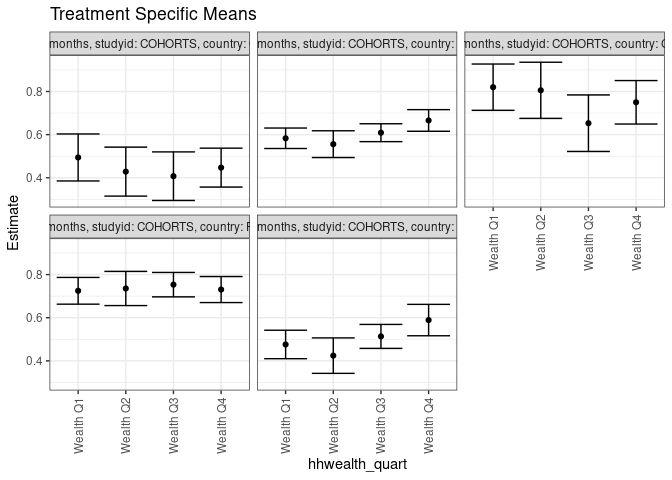

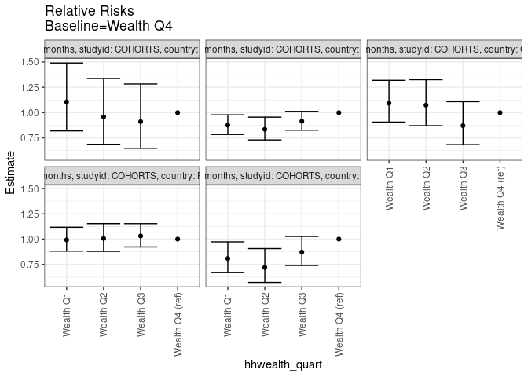

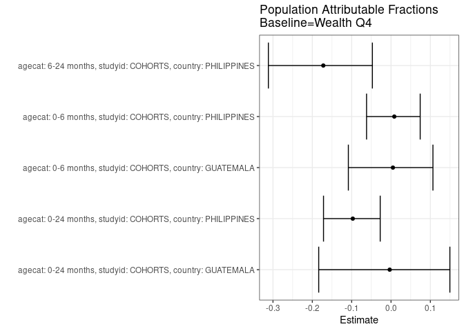

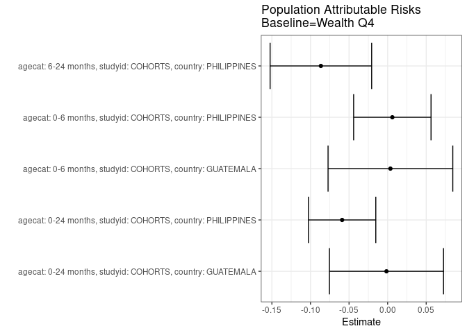

## Results Table

### Parameter: TSM

| agecat | studyid | country | intervention_level | baseline_level | estimate | ci_lower | ci_upper |
| --- | --- | --- | --- | --- | --- | --- | --- |
| 0-24 months | COHORTS | GUATEMALA | Wealth Q4 | NA | 0.4471545 | 0.3569854 | 0.5373236 |
| 0-24 months | COHORTS | GUATEMALA | Wealth Q1 | NA | 0.4942529 | 0.3852897 | 0.6032161 |
| 0-24 months | COHORTS | GUATEMALA | Wealth Q2 | NA | 0.4285714 | 0.3150080 | 0.5421349 |
| 0-24 months | COHORTS | GUATEMALA | Wealth Q3 | NA | 0.4074074 | 0.2948140 | 0.5200008 |
| 0-24 months | COHORTS | PHILIPPINES | Wealth Q4 | NA | 0.6658416 | 0.6156941 | 0.7159891 |
| 0-24 months | COHORTS | PHILIPPINES | Wealth Q1 | NA | 0.5831435 | 0.5356939 | 0.6305931 |
| 0-24 months | COHORTS | PHILIPPINES | Wealth Q2 | NA | 0.5559441 | 0.4939019 | 0.6179862 |
| 0-24 months | COHORTS | PHILIPPINES | Wealth Q3 | NA | 0.6089286 | 0.5675004 | 0.6503567 |
| 0-6 months | COHORTS | GUATEMALA | Wealth Q4 | NA | 0.7500000 | 0.6492506 | 0.8507494 |
| 0-6 months | COHORTS | GUATEMALA | Wealth Q1 | NA | 0.8200000 | 0.7127330 | 0.9272670 |
| 0-6 months | COHORTS | GUATEMALA | Wealth Q2 | NA | 0.8055556 | 0.6753282 | 0.9357829 |
| 0-6 months | COHORTS | GUATEMALA | Wealth Q3 | NA | 0.6530612 | 0.5220152 | 0.7841072 |
| 0-6 months | COHORTS | PHILIPPINES | Wealth Q4 | NA | 0.7305936 | 0.6702821 | 0.7909052 |
| 0-6 months | COHORTS | PHILIPPINES | Wealth Q1 | NA | 0.7248677 | 0.6628824 | 0.7868530 |
| 0-6 months | COHORTS | PHILIPPINES | Wealth Q2 | NA | 0.7355372 | 0.6562866 | 0.8147878 |
| 0-6 months | COHORTS | PHILIPPINES | Wealth Q3 | NA | 0.7533632 | 0.6966900 | 0.8100364 |
| 6-24 months | COHORTS | PHILIPPINES | Wealth Q4 | NA | 0.5891892 | 0.5164024 | 0.6619760 |
| 6-24 months | COHORTS | PHILIPPINES | Wealth Q1 | NA | 0.4760000 | 0.4100748 | 0.5419252 |
| 6-24 months | COHORTS | PHILIPPINES | Wealth Q2 | NA | 0.4242424 | 0.3419677 | 0.5065172 |
| 6-24 months | COHORTS | PHILIPPINES | Wealth Q3 | NA | 0.5133531 | 0.4577706 | 0.5689356 |

### Parameter: E(Y)

| agecat | studyid | country | intervention_level | baseline_level | estimate | ci_lower | ci_upper |
| --- | --- | --- | --- | --- | --- | --- | --- |
| 0-24 months | COHORTS | GUATEMALA | NA | NA | 0.4456522 | 0.3930622 | 0.4982422 |
| 0-24 months | COHORTS | PHILIPPINES | NA | NA | 0.6068680 | 0.5823645 | 0.6313715 |
| 0-6 months | COHORTS | GUATEMALA | NA | NA | 0.7536232 | 0.6949302 | 0.8123162 |
| 0-6 months | COHORTS | PHILIPPINES | NA | NA | 0.7367021 | 0.7051294 | 0.7682749 |
| 6-24 months | COHORTS | PHILIPPINES | NA | NA | 0.5026681 | 0.4688378 | 0.5364984 |

### Parameter: RR

| agecat | studyid | country | intervention_level | baseline_level | estimate | ci_lower | ci_upper |
| --- | --- | --- | --- | --- | --- | --- | --- |
| 0-24 months | COHORTS | GUATEMALA | Wealth Q4 | Wealth Q4 | 1.0000000 | 1.0000000 | 1.0000000 |
| 0-24 months | COHORTS | GUATEMALA | Wealth Q1 | Wealth Q4 | 1.1053292 | 0.8197376 | 1.4904190 |
| 0-24 months | COHORTS | GUATEMALA | Wealth Q2 | Wealth Q4 | 0.9584416 | 0.6869861 | 1.3371597 |
| 0-24 months | COHORTS | GUATEMALA | Wealth Q3 | Wealth Q4 | 0.9111111 | 0.6470918 | 1.2828527 |
| 0-24 months | COHORTS | PHILIPPINES | Wealth Q4 | Wealth Q4 | 1.0000000 | 1.0000000 | 1.0000000 |
| 0-24 months | COHORTS | PHILIPPINES | Wealth Q1 | Wealth Q4 | 0.8757992 | 0.7838829 | 0.9784933 |
| 0-24 months | COHORTS | PHILIPPINES | Wealth Q2 | Wealth Q4 | 0.8349494 | 0.7297526 | 0.9553109 |
| 0-24 months | COHORTS | PHILIPPINES | Wealth Q3 | Wealth Q4 | 0.9145247 | 0.8262451 | 1.0122365 |
| 0-6 months | COHORTS | GUATEMALA | Wealth Q4 | Wealth Q4 | 1.0000000 | 1.0000000 | 1.0000000 |
| 0-6 months | COHORTS | GUATEMALA | Wealth Q1 | Wealth Q4 | 1.0933333 | 0.9064025 | 1.3188156 |
| 0-6 months | COHORTS | GUATEMALA | Wealth Q2 | Wealth Q4 | 1.0740741 | 0.8704625 | 1.3253129 |
| 0-6 months | COHORTS | GUATEMALA | Wealth Q3 | Wealth Q4 | 0.8707483 | 0.6839437 | 1.1085747 |
| 0-6 months | COHORTS | PHILIPPINES | Wealth Q4 | Wealth Q4 | 1.0000000 | 1.0000000 | 1.0000000 |
| 0-6 months | COHORTS | PHILIPPINES | Wealth Q1 | Wealth Q4 | 0.9921627 | 0.8809754 | 1.1173829 |
| 0-6 months | COHORTS | PHILIPPINES | Wealth Q2 | Wealth Q4 | 1.0067665 | 0.8789824 | 1.1531276 |
| 0-6 months | COHORTS | PHILIPPINES | Wealth Q3 | Wealth Q4 | 1.0311659 | 0.9221973 | 1.1530105 |
| 6-24 months | COHORTS | PHILIPPINES | Wealth Q4 | Wealth Q4 | 1.0000000 | 1.0000000 | 1.0000000 |
| 6-24 months | COHORTS | PHILIPPINES | Wealth Q1 | Wealth Q4 | 0.8078899 | 0.6710549 | 0.9726270 |
| 6-24 months | COHORTS | PHILIPPINES | Wealth Q2 | Wealth Q4 | 0.7200445 | 0.5721405 | 0.9061831 |
| 6-24 months | COHORTS | PHILIPPINES | Wealth Q3 | Wealth Q4 | 0.8712874 | 0.7393119 | 1.0268220 |

### Parameter: PAR

| agecat | studyid | country | intervention_level | baseline_level | estimate | ci_lower | ci_upper |
| --- | --- | --- | --- | --- | --- | --- | --- |
| 0-24 months | COHORTS | GUATEMALA | Wealth Q4 | NA | -0.0015023 | -0.0754398 | 0.0724353 |
| 0-24 months | COHORTS | PHILIPPINES | Wealth Q4 | NA | -0.0589736 | -0.1026060 | -0.0153412 |
| 0-6 months | COHORTS | GUATEMALA | Wealth Q4 | NA | 0.0036232 | -0.0772108 | 0.0844571 |
| 0-6 months | COHORTS | PHILIPPINES | Wealth Q4 | NA | 0.0061085 | -0.0440476 | 0.0562646 |
| 6-24 months | COHORTS | PHILIPPINES | Wealth Q4 | NA | -0.0865211 | -0.1523281 | -0.0207141 |

### Parameter: PAF

| agecat | studyid | country | intervention_level | baseline_level | estimate | ci_lower | ci_upper |
| --- | --- | --- | --- | --- | --- | --- | --- |
| 0-24 months | COHORTS | GUATEMALA | Wealth Q4 | NA | -0.0033710 | -0.1837913 | 0.1495516 |
| 0-24 months | COHORTS | PHILIPPINES | Wealth Q4 | NA | -0.0971770 | -0.1715762 | -0.0275024 |
| 0-6 months | COHORTS | GUATEMALA | Wealth Q4 | NA | 0.0048077 | -0.1084546 | 0.1064968 |
| 0-6 months | COHORTS | PHILIPPINES | Wealth Q4 | NA | 0.0082917 | -0.0621976 | 0.0741032 |
| 6-24 months | COHORTS | PHILIPPINES | Wealth Q4 | NA | -0.1721237 | -0.3117148 | -0.0473877 |